# Практика 37 · Жорсткість і сплайн

> 📖 **Теорія:** відкрий `lecture.html` у цій же теці. 📝 **Домашнє завдання:** `homework.md` · 🧪 **Тест:** `quiz.html` ⏮ Перша частина теми: `../36-double-descent/`

У першій частині ми **побачили** подвійний спуск. Тут ми його **порахуємо** — на моделі, де все можна перевірити руками: шість точок і кусково-лінійна функція з випадковими зламами.

## 1. Дані: шість точок параболи, без жодного шуму

Дані навмисно крихітні. Відсутність шуму принципова: ми хочемо показати, що пік на порозі виникає **навіть на ідеально чистих даних** — тобто це властивість самої моделі, а не забруднення міток.

```python
import numpy as np
import matplotlib.pyplot as plt

X_ДАНІ = np.array([0.0, 1.0, 2.0, 3.0, 4.0, 5.0])
КІЛЬКІСТЬ_ТОЧОК = len(X_ДАНІ)          # це і є N
ЛІВА_МЕЖА, ПРАВА_МЕЖА = 0.0, 5.0


def істинна_функція(x):
    """Парабола з вершиною в 2.5. Саме її модель має відновити між точками."""
    return 4.0 * (np.asarray(x, dtype=float) - 2.5) ** 2


Y_ДАНІ = істинна_функція(X_ДАНІ)

print(f"N = {КІЛЬКІСТЬ_ТОЧОК} точок")
print(f"x = {X_ДАНІ}")
print(f"y = {Y_ДАНІ}")
print("\nШуму немає взагалі: y — це точні значення параболи.")
```

```
N = 6 точок
x = [0. 1. 2. 3. 4. 5.]
y = [25.  9.  1.  1.  9. 25.]

Шуму немає взагалі: y — це точні значення параболи.
```

## 2. Модель: ламана зі зламами у випадкових вузлах

Модель — кусково-лінійна функція, у якої злами дозволені **лише** в заздалегідь кинутих точках t₁ … t_K (їх називають **вузлами**, knots):

f(x) = α + β·x + γ₁·φ₁(x) + … + γ_K·φ_K(x), де φ_k(x) = ½·|x − t_k|

Чому саме модуль? Бо |x − t| лінійна всюди, крім самої точки t, де вона зламується. Сума таких доданків плюс пряма α + βx — це ламана з дозволеними зламами рівно у вузлах.

**Вузли не навчаються.** Вони кидаються випадково й далі стоять нерухомо. Навчаються тільки коефіцієнти α, β, γ. Тому задача лишається звичайною лінійною регресією — просто в нестандартному базисі.

Параметрів у моделі **p = K + 2**: два на пряму й по одному на кожен вузол. Отже поріг інтерполяції p = N досягається при **K = N − 2 = 4** вузли.

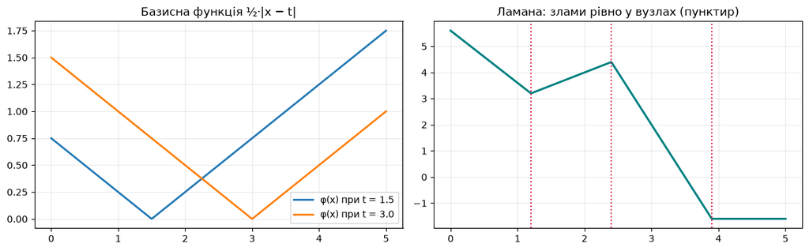

```
Кусково-лінійні функції — це рівно те, що вміє будувати мережа з ReLU.
Тому висновки цієї практики переносяться далі, ніж здається.
```

```python
def базисна_функція(x, вузол):
    """½·|x − t| — та сама «галочка», яка ламає нахил рівно на одиницю."""
    return 0.5 * np.abs(np.asarray(x, dtype=float) - вузол)


def матриця_плану(x, вузли):
    """Стовпці: [1, x, φ₁(x), …, φ_K(x)]. Розмір: len(x) × (K + 2)."""
    x = np.asarray(x, dtype=float)
    стовпці = [np.ones_like(x), x]
    for вузол in вузли:
        стовпці.append(базисна_функція(x, вузол))
    return np.column_stack(стовпці)


# як виглядає одна базисна функція і одна ламана з неї
сітка = np.linspace(ЛІВА_МЕЖА, ПРАВА_МЕЖА, 600)
fig, (ліва, права) = plt.subplots(1, 2, figsize=(12, 3.8))

for вузол in [1.5, 3.0]:
    ліва.plot(сітка, базисна_функція(сітка, вузол), lw=2, label=f"φ(x) при t = {вузол}")
ліва.set_title("Базисна функція ½·|x − t|"); ліва.legend(); ліва.grid(alpha=.25)

приклад_вузлів = [1.2, 2.4, 3.9]
приклад_коефіцієнтів = np.array([2.0, -1.0, 3.0, -5.0, 4.0])   # α, β, γ₁, γ₂, γ₃
права.plot(сітка, матриця_плану(сітка, приклад_вузлів) @ приклад_коефіцієнтів, lw=2.2, color="teal")
for вузол in приклад_вузлів:
    права.axvline(вузол, color="crimson", ls=":", lw=1.4)
права.set_title("Ламана: злами рівно у вузлах (пунктир)"); права.grid(alpha=.25)
plt.tight_layout(); plt.show()

print("Кусково-лінійні функції — це рівно те, що вміє будувати мережа з ReLU.")
print("Тому висновки цієї практики переносяться далі, ніж здається.")
```

## 3. Правило підгонки

Так само, як у першій частині, але з однією важливою деталлю:

- **p < N** — звичайний метод найменших квадратів.
- **p ≥ N** — інтерполянтів багато; беремо той, у якого мінімальна **‖γ‖²**. Коефіцієнти α і β у норму **не входять**: пряма — «безкоштовна» частина моделі, штрафувати її немає сенсу.

Ця деталь заважає просто написати `pinv`: він мінімізував би довжину всього вектора, включно з α і β. Тому спершу приберемо пряму з рівнянь.

**Як прибрати.** Помножимо систему Aθ = y на матрицю, рядки якої ортогональні до стовпців «1» і «x». Тоді доданки α·1 і β·x зникають, і залишається система тільки на γ — розміром (N − 2) × K. Її вже можна розвʼязувати через `pinv`, і мінімальна норма буде саме тією, що потрібно.

```python
# ортонормований базис доповнення до площини span{1, x} у просторі R^N
пряма_на_точках = np.column_stack([np.ones(КІЛЬКІСТЬ_ТОЧОК), X_ДАНІ])
ліві_вектори, _, _ = np.linalg.svd(пряма_на_точках, full_matrices=True)
ДОПОВНЕННЯ = ліві_вектори[:, 2:]          # N × (N − 2) = 6 × 4

print(f"матриця доповнення: {ДОПОВНЕННЯ.shape}")
print(f"перевірка ортогональності до «1» і до «x»: "
      f"{np.max(np.abs(ДОПОВНЕННЯ.T @ пряма_на_точках)):.2e}")


def навчити(вузли):
    """Коефіцієнти (α, β, γ₁ … γ_K) за правилом «МНК до порогу, мінімальна ‖γ‖ після»."""
    A = матриця_плану(X_ДАНІ, вузли)
    кількість_параметрів = len(вузли) + 2

    if кількість_параметрів < КІЛЬКІСТЬ_ТОЧОК:
        коефіцієнти, *_ = np.linalg.lstsq(A, Y_ДАНІ, rcond=None)
        return коефіцієнти

    # 1) прибираємо α і β з рівнянь — лишається система тільки на γ
    система_на_гамма = ДОПОВНЕННЯ.T @ A[:, 2:]
    права_частина = ДОПОВНЕННЯ.T @ Y_ДАНІ
    гамма = np.linalg.pinv(система_на_гамма) @ права_частина    # мінімальна ‖γ‖

    # 2) знаючи γ, добираємо α і β так, щоб крива пройшла крізь усі точки
    залишок = Y_ДАНІ - A[:, 2:] @ гамма
    альфа_бета, *_ = np.linalg.lstsq(пряма_на_точках, залишок, rcond=None)
    return np.concatenate([альфа_бета, гамма])


def прогноз(коефіцієнти, вузли, x):
    return матриця_плану(x, вузли) @ коефіцієнти


def норма_гамма(коефіцієнти):
    """Довжина вектора коефіцієнтів при вузлах — без α і β."""
    return np.linalg.norm(коефіцієнти[2:])


def сума_залишків(коефіцієнти, вузли):
    """Наскільки крива промахнулась повз шість точок даних."""
    return np.sum(np.abs(Y_ДАНІ - прогноз(коефіцієнти, вузли, X_ДАНІ)))


def похибка_проти_істини(коефіцієнти, вузли, кроків=401):
    """Середнє відхилення від параболи на всьому відрізку, а не лише в шести точках."""
    сітка_оцінки = np.linspace(ЛІВА_МЕЖА, ПРАВА_МЕЖА, кроків)
    відхилення = прогноз(коефіцієнти, вузли, сітка_оцінки) - істинна_функція(сітка_оцінки)
    return np.mean(np.abs(відхилення))
```

```
матриця доповнення: (6, 4)
перевірка ортогональності до «1» і до «x»: 9.99e-16
```

### Перевірка: чи справді від K = 4 модель інтерполює

Порогу відповідає K = 4. Починаючи з нього сума залишків має стати нулем — але **лише якщо вузли розкидані по відрізку**. Чому так, зрозуміти легко: між двома сусідніми вузлами функція строго пряма, а пряма не пройде крізь три точки параболи, які не лежать на одній лінії. Тому в кожній «дірці» шириною у дві сусідні точки має бути хоч один злам.

```python
# розкидані вузли: по одному в кожному проміжку між точками даних
ПРИКЛАДИ_ВУЗЛІВ = {
    0: np.array([]),
    1: np.array([2.5]),
    2: np.array([1.5, 3.5]),
    3: np.array([1.5, 2.5, 3.5]),
    4: np.array([0.5, 1.5, 2.5, 3.5]),
    6: np.array([0.4, 1.2, 1.8, 2.6, 3.4, 4.2]),
    12: np.linspace(0.2, 4.8, 12),
    40: np.linspace(0.05, 4.95, 40),
}

print(f"{'K':>4} {'p':>4} {'сума залишків':>16} {'‖γ‖':>10} {'похибка проти істини':>22}")
for K, вузли in ПРИКЛАДИ_ВУЗЛІВ.items():
    коеф = навчити(вузли)
    мітка = "  ← ПОРІГ" if K == КІЛЬКІСТЬ_ТОЧОК - 2 else ""
    print(f"{K:>4} {K + 2:>4} {сума_залишків(коеф, вузли):16.2e} {норма_гамма(коеф):10.2f} "
          f"{похибка_проти_істини(коеф, вузли):22.3f}{мітка}")

assert сума_залишків(навчити(ПРИКЛАДИ_ВУЗЛІВ[4]), ПРИКЛАДИ_ВУЗЛІВ[4]) < 1e-8
assert сума_залишків(навчити(ПРИКЛАДИ_ВУЗЛІВ[12]), ПРИКЛАДИ_ВУЗЛІВ[12]) < 1e-8
print("\n✅ від K = 4 модель проходить крізь усі шість точок точно")
```

```
   K    p    сума залишків        ‖γ‖   похибка проти істини
   0    2         5.33e+01       0.00                  7.308
   1    3         1.07e+01      24.00                  1.988
   2    4         5.33e-14      22.63                  0.931
   3    5         2.53e-14      22.63                  0.931
   4    6         3.55e-14      22.63                  0.931  ← ПОРІГ
   6    8         3.73e-14      14.76                  0.251
  12   14         2.53e-14      10.80                  0.153
  40   42         5.62e-14       5.97                  0.133

✅ від K = 4 модель проходить крізь усі шість точок точно
```

### А якщо вузли збилися в купу

Тепер зворотний бік. Кинемо чотири вузли так, щоб усі вони опинились праворуч від x = 2. Тоді на відрізку [0, 2] функція — одна пряма, а точки (0, 25), (1, 9), (2, 1) на одній прямій не лежать. Інтерполянта просто **не існує**, і модель змушена промахнутись.

```python
ЗБИТІ_ВУЗЛИ = np.array([2.7, 3.0, 3.6, 4.7])
коеф_збиті = навчити(ЗБИТІ_ВУЗЛИ)
print(f"вузли зліплені праворуч: {ЗБИТІ_ВУЗЛИ}")
print(f"сума залишків = {сума_залишків(коеф_збиті, ЗБИТІ_ВУЗЛИ):.3f}  — не нуль!")
print(f"розкидані вузли:         {ПРИКЛАДИ_ВУЗЛІВ[4]}")
print(f"сума залишків = {сума_залишків(навчити(ПРИКЛАДИ_ВУЗЛІВ[4]), ПРИКЛАДИ_ВУЗЛІВ[4]):.2e}")

# наскільки часто випадковий розклад узагалі не дає інтерполянта
rng = np.random.default_rng(0)
print(f"\n{'K':>4} {'розкладів без інтерполянта':>28}")
for K in [4, 5, 6, 8, 12, 20]:
    невдач = 0
    for _ in range(400):
        вузли = np.sort(rng.uniform(ЛІВА_МЕЖА, ПРАВА_МЕЖА, K))
        if сума_залишків(навчити(вузли), вузли) > 1e-6:
            невдач += 1
    print(f"{K:>4} {100 * невдач / 400:27.1f}%")

assert сума_залишків(коеф_збиті, ЗБИТІ_ВУЗЛИ) > 1.0
print("\n✅ на самому порозі більш ніж половина випадкових розкладів не дає інтерполянта")
print("Це та сама жорсткість, тільки в найгострішій формі: свободи настільки мало,")
print("що іноді її не вистачає навіть на те, щоб пройти крізь дані.")
```

```
вузли зліплені праворуч: [2.7 3.  3.6 4.7]
сума залишків = 5.333  — не нуль!
розкидані вузли:         [0.5 1.5 2.5 3.5]
сума залишків = 3.55e-14

   K   розкладів без інтерполянта
   4                        58.0%
```

```
   5                        35.0%
   6                        20.8%
   8                         7.5%
```

```
  12                         0.8%
  20                         0.0%

✅ на самому порозі більш ніж половина випадкових розкладів не дає інтерполянта
Це та сама жорсткість, тільки в найгострішій формі: свободи настільки мало,
що іноді її не вистачає навіть на те, щоб пройти крізь дані.
```